# Scrum

Manish Grewal

30/08/2020

# Measuring SCRUM at XYZ

The technology department with a strength of 75 IT professionals at XYZ company follows SCRUM since the last 3* years as of July 2020. The department is organized into 9 teams who work on various technology applications. Each team has a Scrummaster(SM), a Business Analyst(BA), developers and testers. Scrummasters and BAs are typically part of more than one team.

All the SCRUM teams run a 2 week sprint that starts on Wednesday with Sprint Planning and ends on Tuesday with a Sprint Review. The teams work on User Stories and play a planning poker dring sprint planning to decide the story points for each. The story points follow a fibonacci scale of 1, 2, 3, 5, 8, 13 and in rare cases 21. The higher the complexity and effort, higher the points.

During the Sprint Planning, the teams assign points to the stories and commit to a few stories out of a prioritized list that they are confident of completing within the Sprint. Each story has a checklist of things to be completed to make it shippable. This is called the Definition of Done(DoD) that needs to be met to complete the story. The incomplete stories are spilled over to the next sprint.

The total number of story points committed by each team are compared with the total number of story points delivered to calculate the delivery percentage. The average delivery percentage is considered one of the indicators of a SCRUM teams performance.

```
##      PI Sprint        Team                Project Committed Delivered Delpct
## 1  20-3  20-14     Polaris  CAT Angular Migration        42        42    100
## 2  20-3  20-14  FiniteLoop        Catalyst Portal        57        39     68
## 3  20-3  20-14   Performix                Console        32        19     59
## 4  20-3  20-14        Vega  Course player (HTML5)         0         0      0
## 5  20-3  20-14 DataTycoons              Analytics        16        16    100
## 6  20-3  20-14   Mavericks                   LCEC        18        18    100
## 7  20-3  20-14      Titans  Certification Manager        29        24     83
## 8  20-3  20-14    Avengers       Campaign Manager        21        21    100
## 9  20-3  20-13     Polaris  CAT Angular Migration        55        55    100
## 10 20-3  20-13  FiniteLoop        Catalyst Portal        48        48    100
## 11 20-3  20-13   Performix                Console        41        41    100
## 12 20-3  20-13        Vega  Course player (HTML5)        25        17     68
## 13 20-3  20-13 DataTycoons              Analytics        16        16    100
## 14 20-3  20-13   Mavericks                   LCEC        13        13    100
## 15 20-3  20-13      Titans  Certification Manager        45        45    100
## 16 20-3  20-13    Avengers       Campaign Manager        22        22    100
## 17 20-2  20-11     Polaris  CAT Angular Migration        56        48     86
## 18 20-2  20-11  FiniteLoop        Catalyst Portal        54        54    100
## 19 20-2  20-11  Gladiators Catalyst Communication        23        23    100
## 20 20-2  20-11   Performix                Console        45        29     64
```

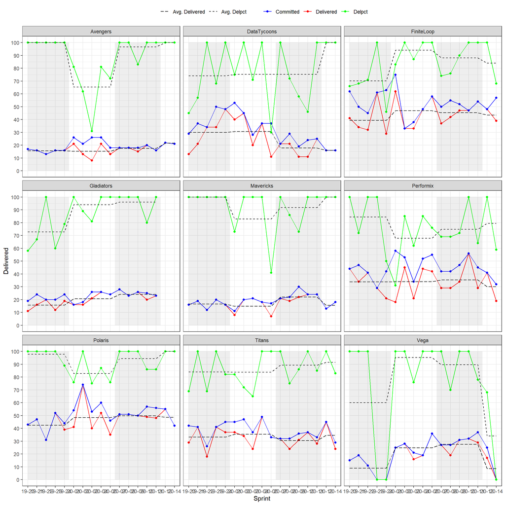

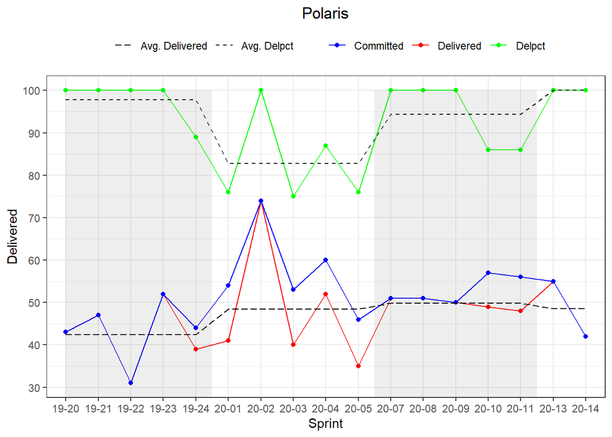

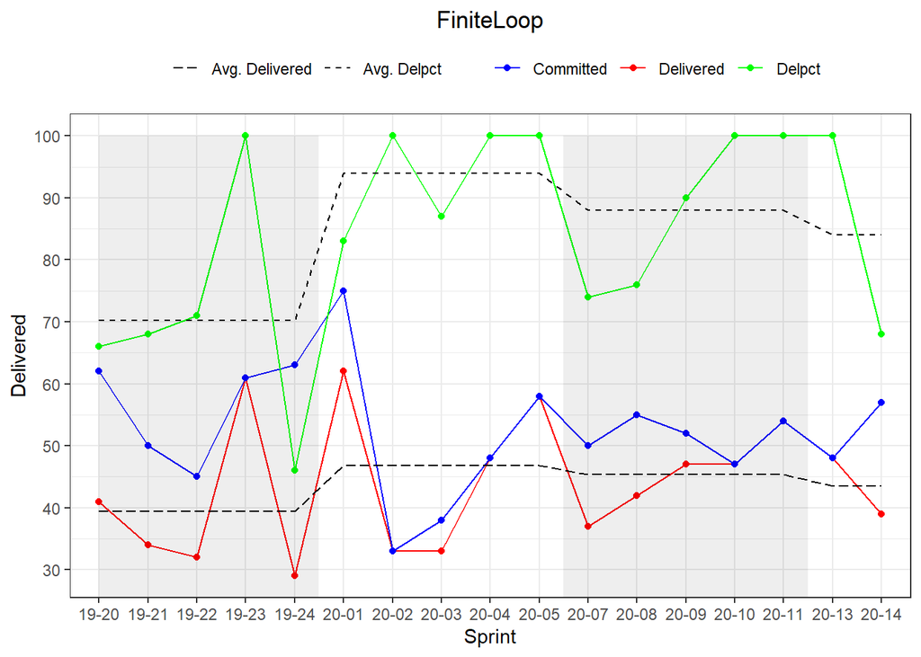

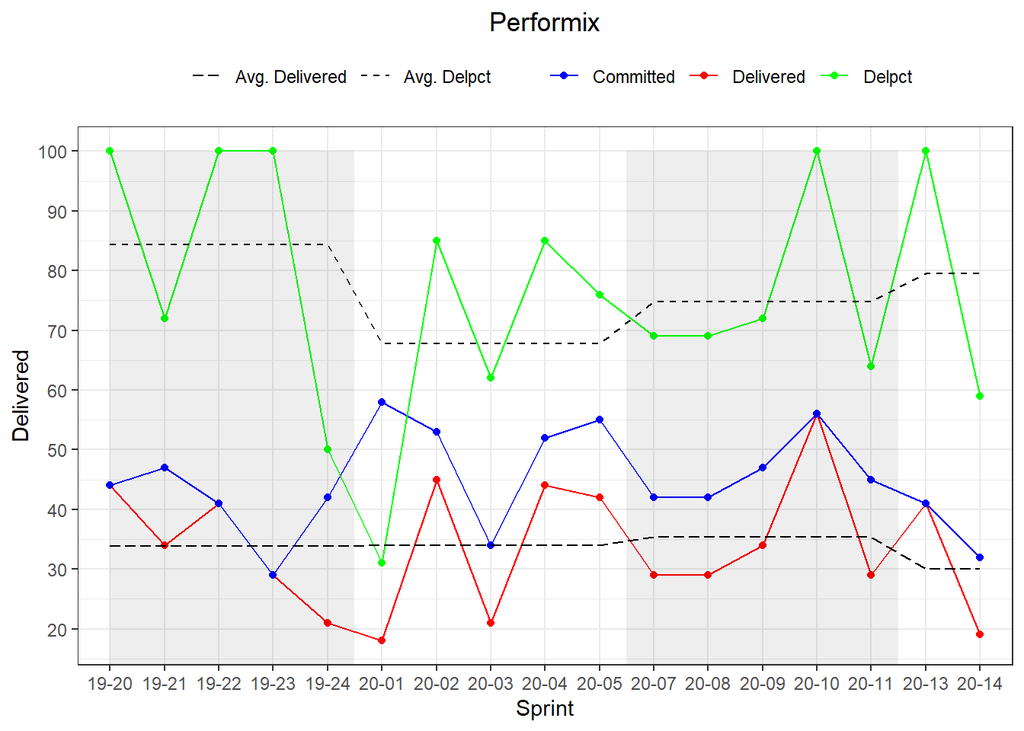

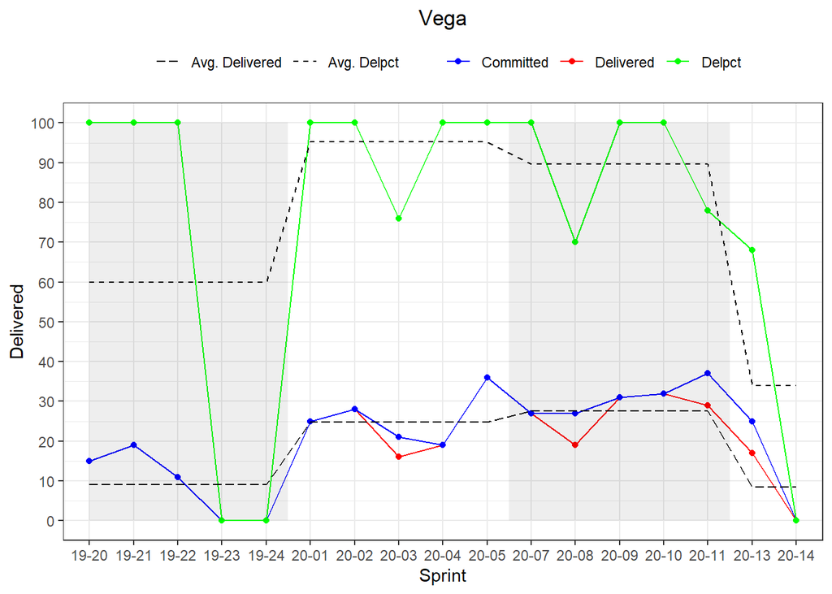

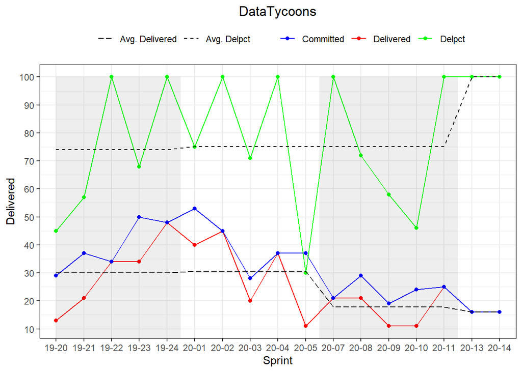

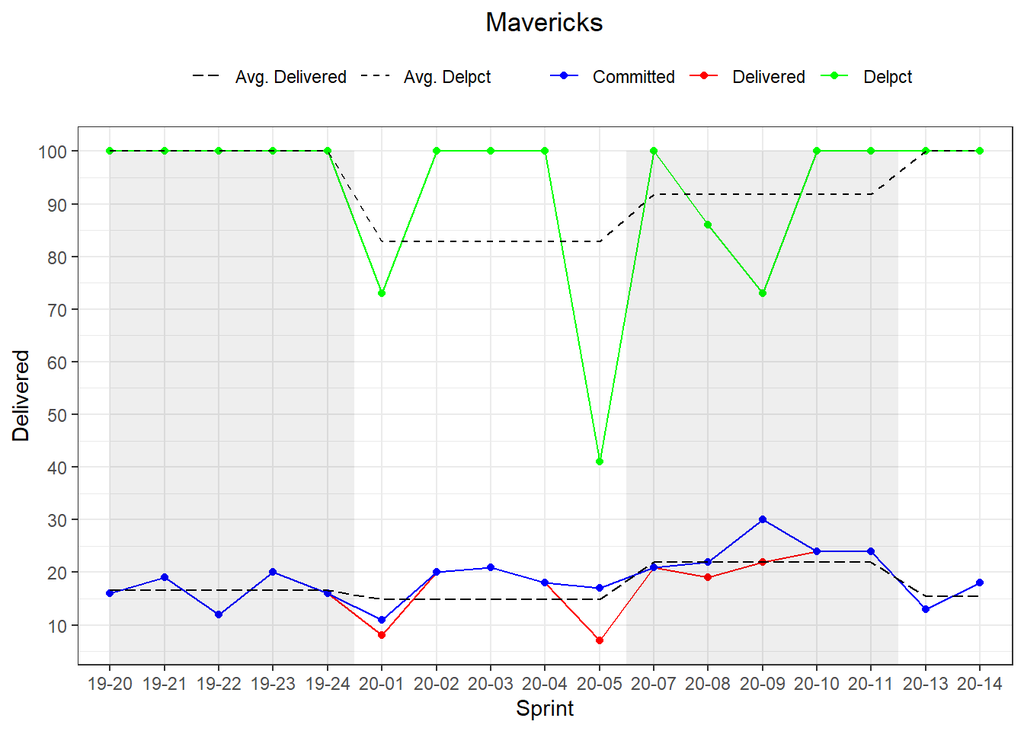

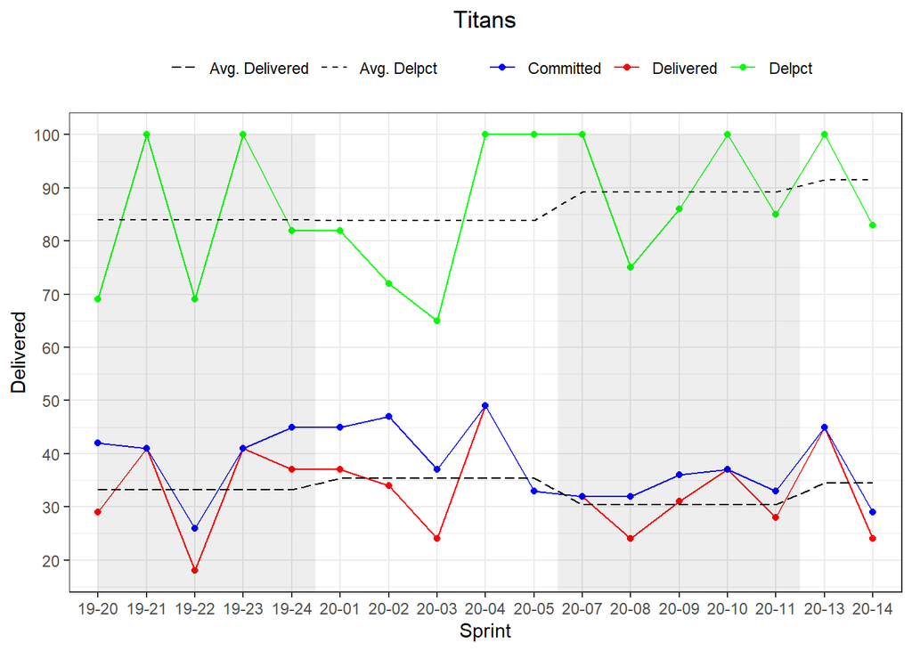

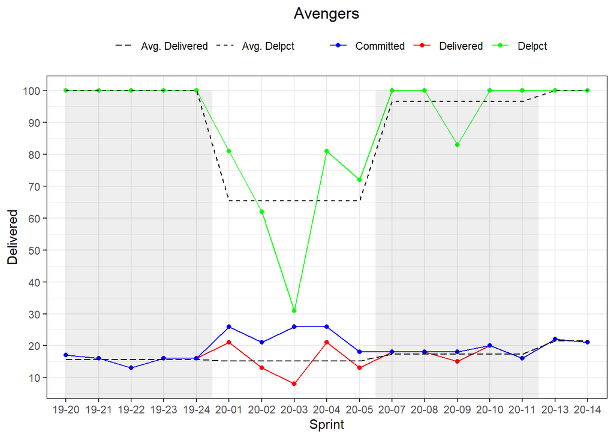

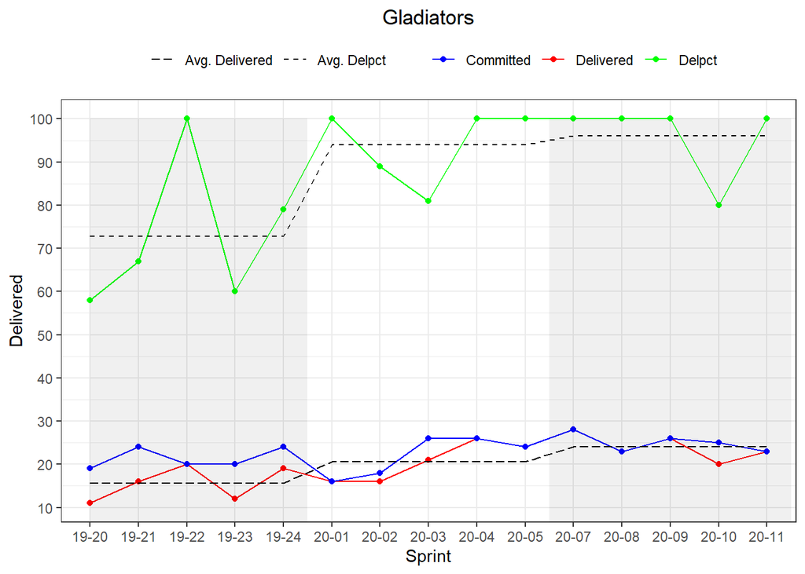